# Combat result panel

In this lesson, we’ll add victory and loss conditions. We’ll display a panel that says “Victory” or “Defeat” depending on who fell on the battlefield.

[figure not shown]

The focus isn’t exactly on the user interface here, but this is an important missing piece of our game demo.

Let’s get started by designing a basic victory panel.

## The victory panel

Our panel is going to be… a panel! With a label.

Create a new scene with a *Panel* named *UICombatResultPanel* as its root and a *Label* as its child. Enlarge *UICombatResultPanel* so it takes quite a bit of space on the screen. I’ve set its size to `(600, 150)`.

We want the text centered inside the panel, and the panel centered on the screen. Apply *Layout -> Center* to both nodes.

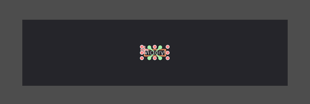

Scale up the label’s bounding box to give the text some space. It stays aligned in the top-left corner.

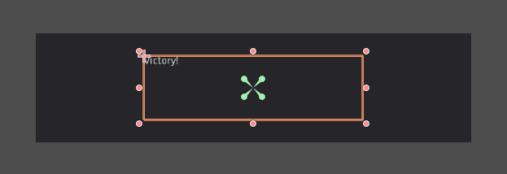

In the *Inspector*, set both its *Align* and *Valign* properties to *Center*.

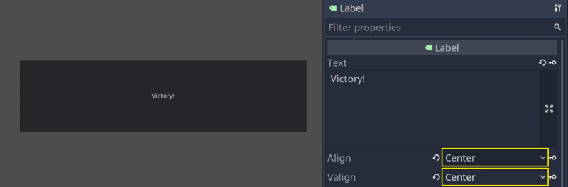

The text is also too small. I’ve prepared a big font for it. Expand its *Custom Fonts* section and assign `text_80p.tres` to the *Font* property. You may need to reapply *Layout -> Center* to the node if its bounding box was too small for the font.

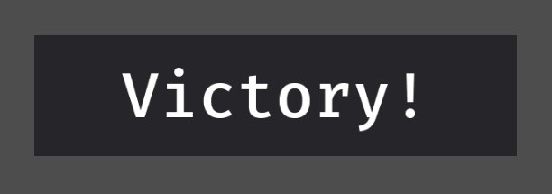

Lastly, you can assign the UI theme we prepared for you to the *UICombatResultPanel*. It will make the panel semi-transparent.

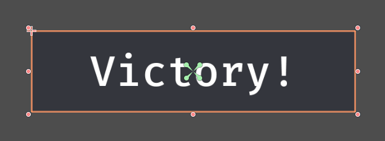

Like we did with the *UIBattlerHUD*, we want to reuse our fade animations.

Right-click the *Panel* and select *Merge From Scene*. Navigate to `UITurnBar.tscn`, open it, and double-click on the *AnimationPlayer* to create a copy of it.

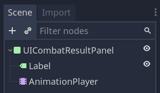

Note that an alternative to reuse the *AnimationPlayer* would be to save it as its own scene. As long as the animations target a scene’s root node, you’ll be able to reuse it anywhere by instantiating it.

The *UICombatResultPanel*’s code is similar to what we’ve done previously. Attach a new script to it.

```
# The tool mode allows us to update the label's text without directly accessing the node.
tool
extends Panel

# We expose a text property to encapsulate the label in the scene.
export var text := "" setget set_text

onready var _label: Label = $Label
onready var _anim_player: AnimationPlayer = $AnimationPlayer


func set_text(value: String) -> void:
    text = value
    # As usual, we have to wait for the node to be ready before we update the label.
    if not is_inside_tree():
        yield(self, "ready")
    _label.text = text


# And here are our fade animations.
func fade_in() -> void:
    _anim_player.play("fade_in")


func fade_out() -> void:
    _anim_player.play("fade_out")
```

## Victory and loss conditions

Let’s code the combat’s end conditions. We’re going to put this code in our `CombatDemo` class. Open `CombatDemo.gd`.

```
# Emitted when all party members or all enemies fell during combat.
# We're using a signal to trigger the panel here.
signal combat_ended(message)

# This enum represents the two possible combat results.
enum CombatResult { DEFEAT, VICTORY }


# We update the ready function to listen to the battler stats' `health_depleted` signal.
func _ready() -> void:
    #..
    for battler in battlers:
        battler.stats.connect("health_depleted", self, "_on_BattlerStats_health_depleted", [battler])


# Returns an array of `Battler` who are in the same team as `actor`, including `actor`.
func get_ally_battlers_of(actor) -> Array:
    var team := []
    # We loop over all battlers on the battlefield.
    for battler in active_turn_queue.battlers:
        # If a battler's in the same party as `actor`, we append it to the array.
        if battler.is_party_member == actor.is_party_member:
            team.append(battler)
    return team


# Returns `true` if all battlers in the array are fallen.
func are_all_fallen(battlers: Array) -> bool:
    # We just count the fallen battlers!
    var fallen_count := 0
    for battler in battlers:
        # We reuse the `is_fallen()` method we already used with the `BattlerAI`.
        if battler.is_fallen():
            fallen_count += 1
    return fallen_count == battlers.size()


# Stops the turn queue, fades out the UI, and emits the `combat_ended` signal
func end_combat(result: int) -> void:
    active_turn_queue.is_active = false
    ui_turn_bar.fade_out()
    ui_battler_hud_list.fade_out()

    var message := "Victory" if result == CombatResult.VICTORY else "Defeat"
    emit_signal("combat_ended", message)


# Every time a battler falls, we get their allies and check if they're all down too.
func _on_BattlerStats_health_depleted(actor) -> void:
    # We make those checks using the two functions we just created.
    var team := get_ally_battlers_of(actor)
    if are_all_fallen(team):
        # And if all fell, we emit the `combat_ended` signal.
        end_combat(CombatResult.DEFEAT if actor.is_party_member else CombatResult.VICTORY)
```

## Displaying the combat result

We have the logic to emit our new signal, but we’re missing a place to connect to it.

I’ve decided to attach a script to the *UI* node, our *CanvasLayer*, and to let it instantiate the *UICombatResultPanel* scene. Attach a script to *UI*:

```
extends CanvasLayer

# We preload the `UICombatResultPanel` scene.
const UICombatResultPanel: PackedScene = preload("UICombatResultPanel.tscn")


# And when the combat ends, we create an instance of it.
func _on_CombatDemo_combat_ended(message) -> void:
    var widget: Control = UICombatResultPanel.instance()
    widget.text = message
    add_child(widget)
```

From the editor’s *Node* dock, connect *CombatDemo*’s `combat_ended` signal to the *UI* node.

And with all that done, the victory or defeat message should appear when all characters die. With the way we coded it, you can also call `CombatDemo.end_combat()` to test the new feature. You can put the call at the end of *CombatDemo*’s `_ready()` function.

[figure not shown]

In the next lesson, we’ll add the damage and miss labels so that the player can see the exact effect of their attacks and applied statuses.